# Task A

## Presentation of results

### "Alcohol Effects On Study" dataset

I presented the "Alcohol Effects On Study" dataset in the previous notebook ([html version](https://github.com/mim-uw/eXplainableMachineLearning-2023/blob/main/Homeworks/HW1/StanislawFrejlak/AlcoholEffectsOnStudy.html), [ipynb version](https://github.com/mim-uw/eXplainableMachineLearning-2023/blob/main/Homeworks/HW1/StanislawFrejlak/AlcoholEffectsOnStudy.ipynb)).

The dataset presents information on many students from two Portuguese school and their final grades. I follow the conclusions from my previous work, and leave in the dataset only nine explanatory variables: 'studytime', 'failures', 'schoolsup', 'famsup', 'paid', 'higher', 'Dalc', 'Walc', 'absences', and variable 'G3' (the final grade) which is to be explained.

In fact, there are two datasets: one for grades in maths, and another one for grades in Portuguese. I performed experiments for both of them but in this report, for simplicity, I focus on the maths dataset.

### Explanatory model - XGBRegressor + SHAP

To predict the final grades of school pupils, this time I use XGBRegressor from the xgboost library. Following the previous experiments, I decided to considerably limit possible tree sizes. I set `max_depth = 3` and `max_leaves = 64`. To compensate for the small tree sizes, I use as much as 500 estimators per model.

Importantly, the focus of this work is not to find the best predictor but to investigate how a given predictor works. Therefore, I don't use a train-test split of the dataset.

To find importances of different variables for model predictions, I use SHAP values. There are two libraries which facilitate it: dalex and shap. For each of them I difined a different XGBRegressor because for dalex it was possible to do it with a simpler code (making use of SciKit-learn Pipelines) and for shap, it was needed to one-hot-encode categorical variables by hand.

### Global feature importances

A good way of getting a general idea about how the boosting model works is by looking at a bee swarm plot (the option is available in the shap library):

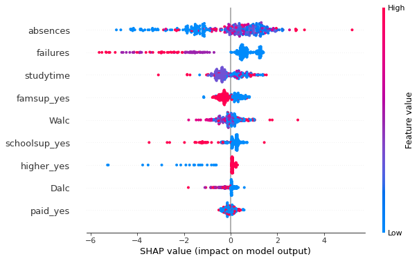

The variables 'failures' and 'higher' have the most clear impact on model predictions. If a pupil failed one or more course before, they will likely get a worse grade this time. The same can be said about pupils who don't want to take higher education.

It was surprising for me that getting an extra educational support (variable 'schoolsup') or a family educational support (variable 'familysup') is correlated with getting worse grades. Perhaps, the support which is mentioned in the dataset is a form of aid which is usually given to worse students. To get a clear picture of this matter, one would need to inquire the dataset creators about more details concerning the variables.

There are also another variables which don't have a big impact on model predictions, or their impact is not clear, e.g. whether a pupil gets extra paid classes within the course subject (variable 'paid'). Interstingly, there is no clear correlation between the number of absences and the final grades. Moreover, visually it seems that the little correlation might be in favor of pupils who skip school more often. However, perhaps one should first remove the outliers and only then try to analyze an impact of a given variable.

### Sample model predictions and their decompositions

I shuffled the dataset and picked pupils number 0 and 314. I got the following predictions: `Model (Pupil[0]) == 12.94` and `Model (Pupil[314]) == 13.02`.

Model's prediction for Pupil 0 is the most impacted by their study time which has value 3 while the mean study time for all pupils is 2.04. Below, there is the prediction's decomposition produced by library dalex:

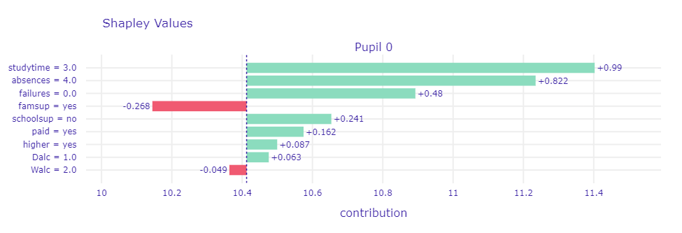

The prediction's decomposition made by library shap is a bit different but similar. The impacts of the variables differ a bit but they are ordered almost the same. Interestingly, alcohol consumptions on weekends of Pupil 0 (which is 2, a little below the mean value for the whole dataset) has a negative contributions to the pupil's grade according to dalex, but a positive contribution according to shap. However, in both cases the contribution is quite small.

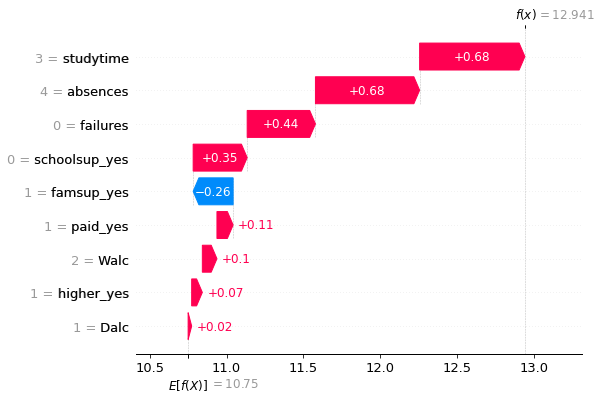

Looking at the plot of variables contributions for Pupil 314, one can see that not always the same variables have the biggest impact. For this pupil, the most important variable is the number of absences. Moreover, this pupil consumes more alcohol on weekends and for them this feature has a big impact on the model's prediction, unlike for Pupil 0.

In general, it's rather understandable for numerical variables that their importance might differ between pupils. If for one pupil a value of a variable is close to the mean value, it likely won't affect much the difference between their final grade and the mean final grade. On the other hand, if for another student a variable takes an extreme value, it might likely have a big impact on their final grade.

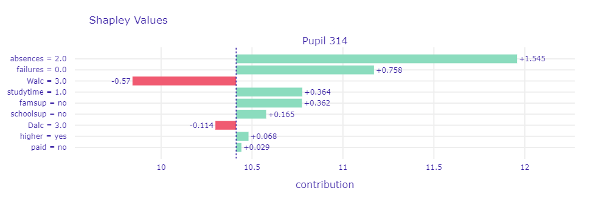

For Pupil 314, variables contributions from the shap library are very similar to the ones from dalex library. There is just one difference in the ordering of the variables and for each variable it has either negative contribution in both libraries, or positive in both.

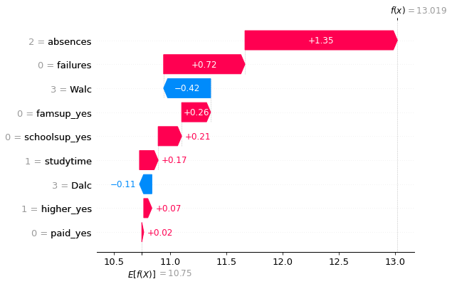

I found one extreme example where the Shapley values are counterintuitive. For Pupil 1, the most important feature is their number of previously failed courses. It is 0 and, as expected, it positively contributes to the prediction of the final grade.

The second most important feature is the number of absences. The pupil wasn't ever absent on the classes and, strangely enough, this fact negatively contributes to the model's prediction.

Even stranger fact is that the pupil consumes a lot of alcohol on weekends (having the maximum possible score of 5), and it has a big positive impact on model's prediction.

Looking at this example, one wants to ask the model more about why the features have such contributions. However, such explanations are not available. Probably, it is just one of few extreme examples where the data are generally different than for most of the students and that's where the unusual contributions stem from.

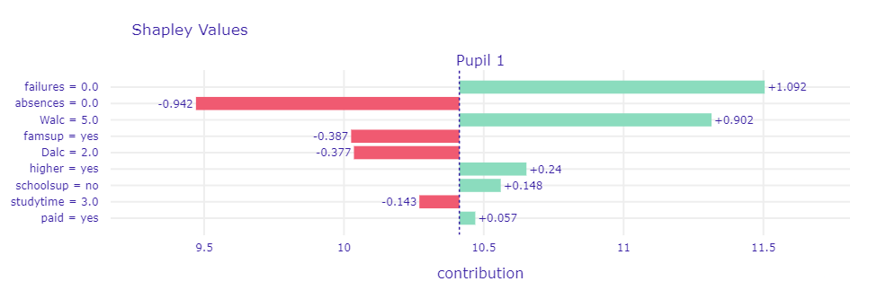

### Discussion

The analysis using Shapley values can capture interesting dependencies which can be viewed globally e.g. on a bee swarm plot. It can provide clues about the model's decision process for every example in the dataset. However, the last example of Pupil 1 showed that sometimes those clues can look quite surprising to a human. Unfortunately, it is not possible to further inquire the model about the reasons why it gave such importances to the given features.

Probably, in this case the small size of the dataset might be partly a culprit for this unexpected behaviour. On the other hand, it might be that in every dataset there would be some outliers for which Shapley values analysis will leave us only with more questions.

## Appendix

```python
!pip install dalex
!pip install shap
```

```python
import dalex as dx
import xgboost
import shap

import sklearn
from sklearn.pipeline import Pipeline
from sklearn.compose import ColumnTransformer
from sklearn.preprocessing import OneHotEncoder
from sklearn.impute import SimpleImputer

import pandas as pd
import numpy as np
```

```python
maths_dataset = pd.read_csv('Maths.csv')
portuguese_dataset = pd.read_csv('Portuguese.csv')
```

```python
def preprocess_dataset(df):
  new_df = df[['studytime', 'failures', 'schoolsup', 'famsup', 'paid', 'higher', 'Dalc', 'Walc', 'absences', 'G3']]\
           .sample(frac=1, random_state=0).reset_index(drop=True)
  new_df.loc[:, df.dtypes == 'object'] = new_df.select_dtypes(['object'])\
                                         .apply(lambda x: x.astype('category'))
  X, y = new_df.drop(columns='G3'), new_df.G3
  return X, y
```

```python
categorical_variables = ['schoolsup', 'famsup', 'paid', 'higher']
numerical_variables = ['studytime', 'failures', 'Dalc', 'Walc', 'absences']
```

```python
def create_pipeline(X, y):
  numerical_transformer = SimpleImputer(strategy='median')
  preprocessor = ColumnTransformer(transformers=[
    ('numerical', numerical_transformer, numerical_variables),
    ('categorical', OneHotEncoder(), categorical_variables)
  ])

  model = xgboost.XGBRegressor(
    n_estimators=500,
    max_depth=3,
    max_leaves=64,
    use_label_encoder=False
  )

  model_pipeline = Pipeline([
        ('preprocessor', preprocessor),
        ('model', model)
  ])
  model_pipeline.fit(X, y)
  return model_pipeline
```

```python
def create_model_ohe(X, y):
  X_ohe = pd.get_dummies(X, columns=categorical_variables, drop_first=True)
  model_ohe = xgboost.XGBRegressor(
    n_estimators=500,
    max_depth=3,
    max_leaves=64,
    use_label_encoder=False
  )
  model_ohe.fit(X_ohe, y)
  return model_ohe, X_ohe
```

```python
def explain_with_dalex(model, X, y, observations=(0, 1, 314)):
  pf_xgboost_classifier_default = lambda m, d: m.predict(d)
  explainer = dx.Explainer(model, X, y, predict_function=pf_xgboost_classifier_default, label="GBM")
  shap_attributions = []
  for i in observations:
    print(f"Pipeline model prediction for the grade of Pupil %d is %.2f" % (i, model.predict(X.iloc[[i]])))
    explainer.predict_parts(X.iloc[[i]], type="shap", label=f"Pupil {i}").plot()
  # shap_attributions[0].plot(shap_attributions[1::])
```

```python
def explain_with_shap(model, X, y, observations=(0, 1, 314)):
  shap_explainer = shap.explainers.Tree(model, data=X, model_output="raw")
  shap_values = shap_explainer(X)
  for i in observations:
    print(f"OHE-Model prediction for the grade of Pupil %d is %.2f" % (i, model.predict(X.iloc[[i]])))
    shap.plots.waterfall(shap_values[i])
  shap.plots.beeswarm(shap_values, max_display=10, plot_size=(9, 6))
```

```python
maths_X, maths_y = preprocess_dataset(maths_dataset)
maths_pipeline = create_pipeline(maths_X, maths_y)
maths_model_ohe, maths_ohe = create_model_ohe(maths_X, maths_y)
maths_ohe.describe()
```

```
[18:38:42] WARNING: /workspace/src/objective/regression_obj.cu:152: reg:linear is now deprecated in favor of reg:squarederror.
[18:38:42] WARNING: /workspace/src/objective/regression_obj.cu:152: reg:linear is now deprecated in favor of reg:squarederror.
```

|  | studytime | failures | Dalc | Walc | absences | schoolsup_yes | famsup_yes | paid_yes | higher_yes |
| --- | --- | --- | --- | --- | --- | --- | --- | --- | --- |
| count | 395.000000 | 395.000000 | 395.000000 | 395.000000 | 395.000000 | 395.000000 | 395.000000 | 395.000000 | 395.000000 |
| mean | 2.035443 | 0.334177 | 1.481013 | 2.291139 | 5.708861 | 0.129114 | 0.612658 | 0.458228 | 0.949367 |
| std | 0.839240 | 0.743651 | 0.890741 | 1.287897 | 8.003096 | 0.335751 | 0.487761 | 0.498884 | 0.219525 |
| min | 1.000000 | 0.000000 | 1.000000 | 1.000000 | 0.000000 | 0.000000 | 0.000000 | 0.000000 | 0.000000 |
| 25% | 1.000000 | 0.000000 | 1.000000 | 1.000000 | 0.000000 | 0.000000 | 0.000000 | 0.000000 | 1.000000 |
| 50% | 2.000000 | 0.000000 | 1.000000 | 2.000000 | 4.000000 | 0.000000 | 1.000000 | 0.000000 | 1.000000 |
| 75% | 2.000000 | 0.000000 | 2.000000 | 3.000000 | 8.000000 | 0.000000 | 1.000000 | 1.000000 | 1.000000 |
| max | 4.000000 | 3.000000 | 5.000000 | 5.000000 | 75.000000 | 1.000000 | 1.000000 | 1.000000 | 1.000000 |

[output not shown]

[interactive chart not shown]

```
Pipeline model prediction for the grade of Pupil 1 is 11.00
```

[interactive chart not shown]

```
Pipeline model prediction for the grade of Pupil 314 is 13.02
```

[interactive chart not shown]

```
OHE-Model prediction for the grade of Pupil 0 is 12.94
```

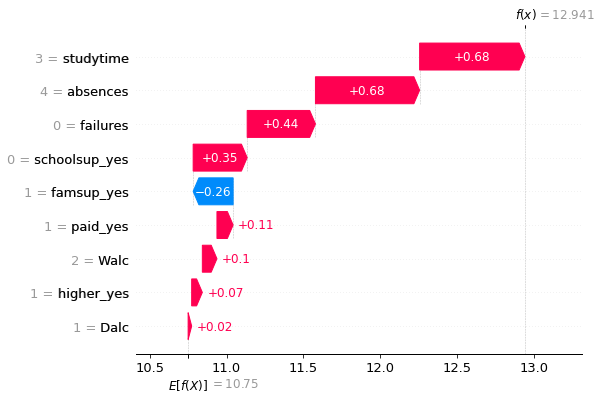

```
OHE-Model prediction for the grade of Pupil 1 is 11.00
```

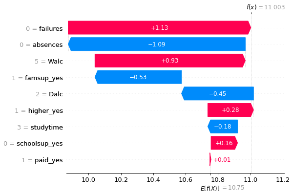

```
OHE-Model prediction for the grade of Pupil 314 is 13.02
```

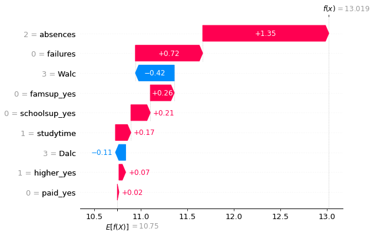

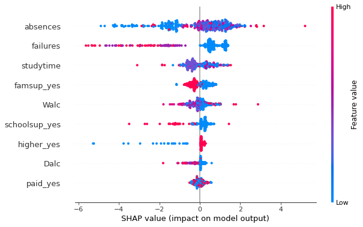

```python
explain_with_dalex(maths_pipeline, maths_X, maths_y)
explain_with_shap(maths_model_ohe, maths_ohe, maths_y)
```

```python
portuguese_X, portuguese_y = preprocess_dataset(portuguese_dataset)
portuguese_model = create_pipeline(portuguese_X, portuguese_y)
portuguese_model_ohe, portuguese_ohe = create_model_ohe(portuguese_X, portuguese_y)
portuguese_ohe.describe()
```

```
[18:38:55] WARNING: /workspace/src/objective/regression_obj.cu:152: reg:linear is now deprecated in favor of reg:squarederror.
[18:38:55] WARNING: /workspace/src/objective/regression_obj.cu:152: reg:linear is now deprecated in favor of reg:squarederror.
```

|  | studytime | failures | Dalc | Walc | absences | schoolsup_yes | famsup_yes | paid_yes | higher_yes |
| --- | --- | --- | --- | --- | --- | --- | --- | --- | --- |
| count | 649.000000 | 649.000000 | 649.000000 | 649.000000 | 649.000000 | 649.000000 | 649.000000 | 649.000000 | 649.000000 |
| mean | 1.930663 | 0.221880 | 1.502311 | 2.280431 | 3.659476 | 0.104777 | 0.613251 | 0.060092 | 0.893683 |
| std | 0.829510 | 0.593235 | 0.924834 | 1.284380 | 4.640759 | 0.306502 | 0.487381 | 0.237841 | 0.308481 |
| min | 1.000000 | 0.000000 | 1.000000 | 1.000000 | 0.000000 | 0.000000 | 0.000000 | 0.000000 | 0.000000 |
| 25% | 1.000000 | 0.000000 | 1.000000 | 1.000000 | 0.000000 | 0.000000 | 0.000000 | 0.000000 | 1.000000 |
| 50% | 2.000000 | 0.000000 | 1.000000 | 2.000000 | 2.000000 | 0.000000 | 1.000000 | 0.000000 | 1.000000 |
| 75% | 2.000000 | 0.000000 | 2.000000 | 3.000000 | 6.000000 | 0.000000 | 1.000000 | 0.000000 | 1.000000 |
| max | 4.000000 | 3.000000 | 5.000000 | 5.000000 | 32.000000 | 1.000000 | 1.000000 | 1.000000 | 1.000000 |

[output not shown]

[interactive chart not shown]

```
OHE-Model prediction for the grade of Pupil 0 is 12.76
```

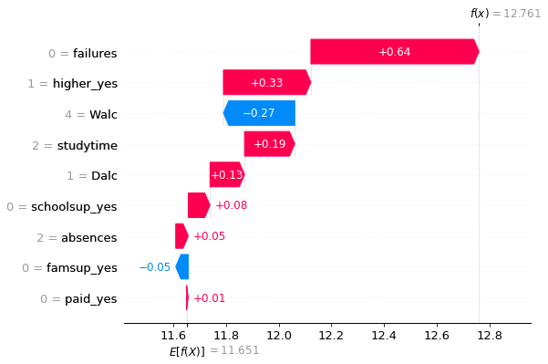

```
OHE-Model prediction for the grade of Pupil 1 is 13.97
```

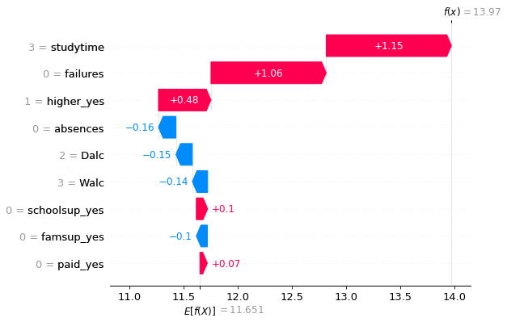

```
OHE-Model prediction for the grade of Pupil 314 is 14.15
```

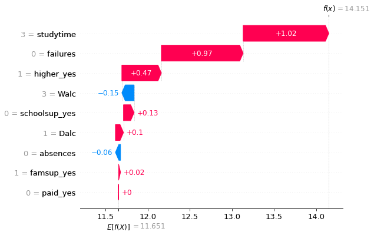

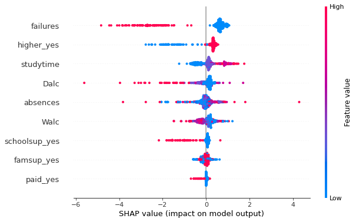

```python
explain_with_dalex(portuguese_model, portuguese_X, portuguese_y)
explain_with_shap(portuguese_model_ohe, portuguese_ohe, portuguese_y)
```

# Task B

Function $v$ takes subsets of the set of players $\{A, B, C\}$ as an arguments and yields a reward the subset gets. It's known that:

$v() = 0$

$v(A) = 20$

$v(B) = 20$

$v(C) = 60$

$v(A,B) = 60$

$v(A,C) = 70$

$v(B,C) = 70$

$v(A,B,C) = 100$

Let's denote by $\phi$ a function assigning Shapley values to players. We calculate:

$\phi(A) = \frac{1}{6} \Big(2v(A) + \big(v(A,B) - v(B)\big) + \big(v(A,C) - v(C)\big) + 2\big( v(A,B,C) - v(B,C)\big) \Big) = \frac{1}{6} \big(2\cdot 20 + (60-20) + (70-60) + 2(100-70)\big) = \frac{150}{6} = 25$

$\phi(B) = \frac{1}{6} \Big(2v(B) + \big(v(A,B) - v(A)\big) + \big(v(B,C) - v(C)\big) + 2\big( v(A,B,C) - v(A,C)\big) \Big) = \frac{1}{6} \big(2\cdot 20 + (60-20) + (70-60) + 2(100-70)\big) = \frac{150}{6} = 25$

$\phi(C) = \frac{1}{6} \Big(2v(C) + \big(v(A,C) - v(C)\big) + \big(v(B,C) - v(B)\big) + 2\big( v(A,B,C) - v(A,B)\big) \Big) = \frac{1}{6} \big(2\cdot 60 + (70-20) + (70-20) + 2(100-60)\big) = \frac{300}{6} = 50$

We have $\phi(A) = \phi(B) = 25$ and $\phi(C) = 50$. The fair split of the reward $A, B$ and $C$ get would be that $A$ and $B$ take 25 each, and $C$ takes 50.

```python
!jupyter nbconvert --to=html ./Homework2.ipynb
```

[output not shown]